# CNV dans un panel de gènes cardiaques — cohorte publique 1000 Genomes

Romain KPAKOU

11 September 2026

## Contexte

Ce rapport reprend, sur données publiques, la méthodologie d’une analyse de variants structuraux (CNV) initialement menée sur une cohorte clinique de 284 patients (prolapsus valvulaire mitral). **Les données patient originales ne sont ni publiées ni publiables** (secret médical, RGPD). L’analyse ci-dessous porte sur le callset public **1000 Genomes Project (Phase 3, GRCh37, 2 504 individus)**, restreint à un panel de 7 gènes associés aux cardiomyopathies et arythmies : *TTN*, *MYH7*, *LMNA*, *DSP*, *PKP2*, *RBM20*, *DES*.

Voir PLAN.md et le README pour le détail méthodologique complet.

## Méthodologie (résumé)

1. Panel de gènes construit à partir des coordonnées GRCh37 réelles (API Ensembl)
2. Filtrage régional du callset SV public (`bedtools intersect`)
3. Annotation fonctionnelle via l’**API REST Ensembl VEP** (GRCh37) — utilisée à la place d’AnnotSV local pour ce dépôt, AnnotSV nécessitant une base d’annotation de plusieurs Go disproportionnée ici pour 14 variants
4. Priorisation par impact fonctionnel (VEP Sequence Ontology) puis par fréquence allélique populationnelle (les variants les plus rares en tête)

## Vue d’ensemble

14 variants structuraux chevauchent le panel de 7 gènes, sur un total de 68 818 variants dans le callset brut.

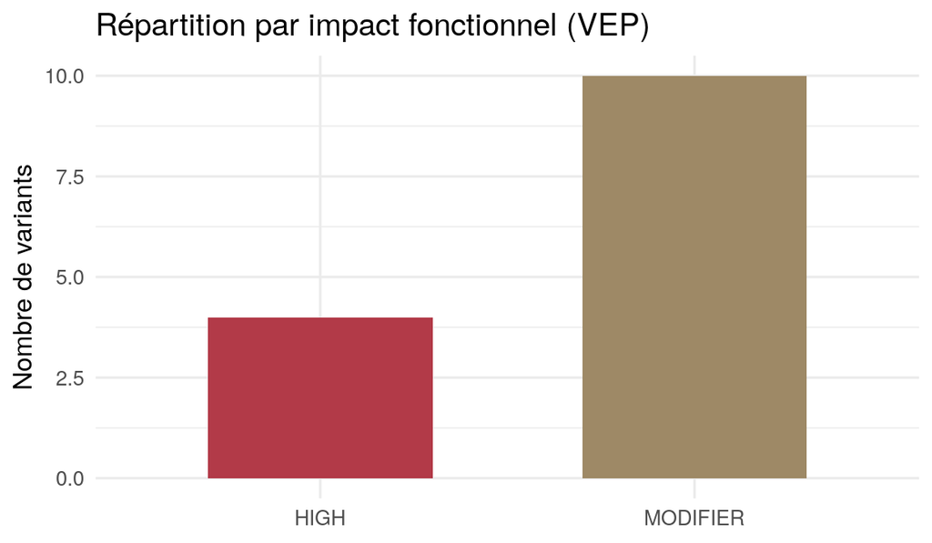

## Variants priorisés

Triés par impact fonctionnel décroissant, puis par fréquence allélique croissante (les variants rares et à fort impact en tête).

| ID | Chr | Début | Fin | Type | Taille (pb) | AF global | Gène(s) | Impact | Conséquences (VEP) |
| --- | --- | --- | --- | --- | --- | --- | --- | --- | --- |
| DUP_gs_CNV_2_179674101_179709787 | 2 | 179674101 | 179709787 | DUP | 35686 | 0.0001997 | CCDC141;RNU7-104P;TTN | HIGH | 3_prime_UTR_variant;5_prime_UTR_variant;coding_sequence_variant;intron_variant;non_coding_transcript_exon_variant;transcript_amplification;upstream_gene_variant |
| YL_CN_MSL_539 | 2 | 179684884 | 179833992 | DEL | 149108 | 0.0001997 | CCDC141;RNU7-104P;TTN | HIGH | 3_prime_UTR_variant;5_prime_UTR_variant;coding_sequence_variant;feature_truncation;intron_variant;stop_lost;transcript_ablation |
| ALU_umary_ALU_1792 | 2 | 179609254 | 179609254 | ALU | 0 | 0.0043930 | TTN;TTN-AS1 | HIGH | 3_prime_UTR_variant;downstream_gene_variant;feature_elongation;intron_variant;non_coding_transcript_variant;upstream_gene_variant |
| BI_GS_CNV_2_179516678_179528763 | 2 | 179516678 | 179528763 | DEL | 12085 | 0.0069888 | TTN;TTN-AS1 | HIGH | 3_prime_UTR_variant;coding_sequence_variant;feature_truncation;intron_variant;non_coding_transcript_variant;stop_lost;upstream_gene_variant |
| L1_umary_LINE1_456 | 2 | 179489788 | 179489788 | LINE1 | 0 | 0.0001997 | TTN;TTN-AS1 | MODIFIER | downstream_gene_variant;intron_variant;non_coding_transcript_variant |
| DEL_pindel_18165 | 6 | 7560631 | 7560773 | DEL | 142 | 0.0001997 | DSP | MODIFIER | intron_variant;non_coding_transcript_variant |
| BI_GS_CNV_12_32956776_32970273 | 12 | 32956776 | 32970273 | DEL | 13497 | 0.0001997 | PKP2 | MODIFIER | downstream_gene_variant;intron_variant;non_coding_transcript_variant |
| DUP_gs_CNV_6_7541771_7549189 | 6 | 7541771 | 7549189 | DUP | 7418 | 0.0007987 | DSP;RP3-512B11.3 | MODIFIER | 5_prime_UTR_variant;coding_sequence_variant;intron_variant;upstream_gene_variant |
| UW_VH_20325 | 10 | 112438454 | 112441973 | DEL | 3519 | 0.0007987 | RBM20 | MODIFIER | intron_variant |
| ALU_umary_ALU_8233 | 10 | 112414352 | 112414352 | ALU | 0 | 0.0015974 | RBM20 | MODIFIER | intron_variant |
| DEL_pindel_35944 | 12 | 32956917 | 32956967 | DEL | 50 | 0.0023962 | PKP2 | MODIFIER | intron_variant;non_coding_transcript_variant |
| ALU_umary_ALU_9133 | 12 | 33016986 | 33016986 | ALU | 0 | 0.0025958 | PKP2;RP11-8P13.1 | MODIFIER | downstream_gene_variant;intron_variant |
| ALU_umary_ALU_1791 | 2 | 179552134 | 179552134 | ALU | 0 | 0.0349441 | TTN;TTN-AS1 | MODIFIER | intron_variant;non_coding_transcript_variant |
| DEL_pindel_35945 | 12 | 32963599 | 32963914 | DEL_ALU | 315 | 0.5748800 | PKP2 | MODIFIER | intron_variant;non_coding_transcript_variant |

## Interprétation

4 variants sont annotés d’impact **HIGH** par VEP, tous localisés dans *TTN* (`feature_truncation`, `stop_lost`, `transcript_ablation`, `transcript_amplification`). *TTN* est le plus grand gène humain (~364 exons) et tolère un nombre élevé de variants structuraux en population générale sans conséquence pathogène établie — un impact VEP “HIGH” reflète l’effet prédit sur le transcrit, **pas** une pathogénicité clinique confirmée.

## Limites

- La cohorte 1000 Genomes est une **population générale**, pas des patients cardiopathes : les CNV identifiés sont des variants de population, pas des variants pathogènes validés.
- Aucune validation fonctionnelle ou clinique n’a été réalisée.
- Ce dépôt démontre une **méthode reproductible de bout en bout**, pas un diagnostic.

## Reproductibilité

```bash
./scripts/00_build_gene_panel.sh
./scripts/01_filter_region.sh
python3 scripts/02_annotate_vep.py
Rscript -e "rmarkdown::render('scripts/03_report.Rmd')"
```